```r
# For data management
library(dplyr)
library(tidyr)

# For graphs
library(ggplot2)
library(ggplotify) # to convert plot() into ggplot object
library(cowplot) # To display plots
library(gridExtra) # To display plots

# kcpRS analysis
library(kcpRS)

# A modificated version of kcpRS to extract PermaTest and Grid search. Used just for a matter of demonstration!
source("FUN_kcpRS_mod.R")
```

# Multivariate Example

```r
library(mvtnorm)

# Simulated data for Multivariate example
m1 = c(1,2,3)
m2 = c(-1,-2,-3)
cr = diag(3)
c1 = diag(3)
c1[1, 2] <- c1[2, 1] <- .7
c1[2, 3] <- c1[3, 2] <- .7
phase1 = rmvnorm(100, m1, cr)
phase2 = rmvnorm(50, m2, c1)
phase3 = rmvnorm(100, m1, cr)
data_multi = rbind(phase1, phase2, phase3)
```

## Time series visualization

First, have a look at your time serie to see if everything is in order.

```r
head(as.data.frame(data_multi))
```

| V1 | V2 | V3 |
| --- | --- | --- |
| 0.6037208 | 2.3469619 | 3.2919976 |
| 1.8135397 | 2.7963855 | 4.6441672 |
| 0.8070010 | 2.2306447 | 4.7448293 |
| 1.1341786 | 0.3707149 | 2.5343108 |
| 0.4697239 | 2.7859930 | 4.4047749 |
| 1.9926130 | 0.1742417 | 0.8548214 |

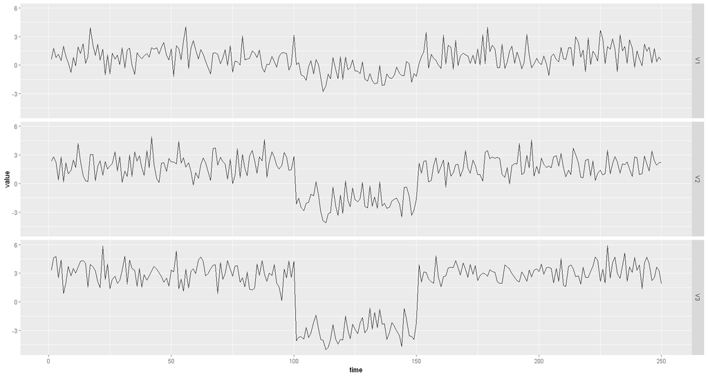

```r
options(repr.plot.width=15, repr.plot.height=8)
plot_multi = as.data.frame(data_multi) %>%
                mutate(time = 1:nrow(data_multi)) %>%
                gather(var, value, V1:V3) %>%
                ggplot(aes(x=time,y=value)) +
                   geom_line() +
                    facet_grid(var~.)
plot_multi
```

## kcpRS analysis using runMean

Using kcpRS function, we can run a change point detection analysis. You should specify the next arguments:

- RS_fun: the metric used which can be runMean, runVar, runAR and runCorr. This is also possible to create your own metric.
- RS_name: give a name to the analysis.
- wsize: specify the size of the window.
- nperm: number of permutations used in the permutation test.
- Kmax: maximum number of change points.
- alpha: significance level of the permutation test
- varTest: if set to FALSE, only the variance DROP test is implemented, and if set to TRUE, both the variance test and the variance DROP tests are implemented.
- ncpu: the number of CPU core used. Specifying detectCores(), your computer will use all its cores.

See more here: https://rdrr.io/cran/kcpRS/man/kcpRS.html

```
SETTINGS:
    Running statistics monitored: Mean
    Number of running Means monitored: 3
    Selected window size: 25
    Number of time windows: 226
    Selected maximum number of change points: 10

    Permutation test: Yes
        Number of permuted data sets used: 1000


OUTPUT:
    Number of change points detected:  2
    Change point location(s):  94 158

    KCP permutation test is significant:
        Significance level: 0.05
        P-value of the variance drop test:  0.004

    Optimal change points given k:
       k   Rmin CP1 CP2 CP3 CP4 CP5 CP6 CP7 CP8 CP9 CP10
       0 0.5130   0   0   0   0   0   0   0   0   0    0
       1 0.4494  92   0   0   0   0   0   0   0   0    0
       2 0.2565  94 158   0   0   0   0   0   0   0    0
       3 0.2216  92 103 157   0   0   0   0   0   0    0
       4 0.1739  92 106 145 160   0   0   0   0   0    0
       5 0.1475  92 106 145 160 216   0   0   0   0    0
       6 0.1276  92 106 143 152 161 216   0   0   0    0
       7 0.1074  92 101 109 142 152 161 216   0   0    0
       8 0.0918  72  92 101 109 142 152 161 216   0    0
       9 0.0826  72  92 101 109 142 149 155 161 216    0
      10 0.0737  72  92 101 109 123 142 149 155 161  216
```

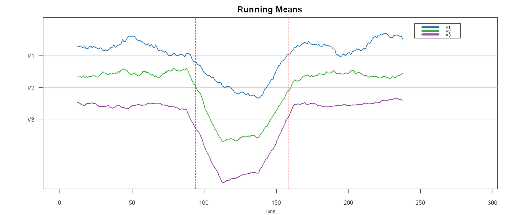

```r
options(repr.plot.width=12, repr.plot.height=5)
# runMean
resultMean = kcpRS(data = data_multi, RS_fun = runMean, RS_name = "Mean",
                      wsize = 25, nperm = 1000, Kmax = 10, alpha = .05, varTest = FALSE,
                      ncpu = detectCores())
summary(resultMean)
plot(resultMean)
```

### How many change points?

How many number of change points should it be extracted from the analysis? In the kcpRS, the decision is based on two methods:

- Permutation test
- Grid search through C penality

A short precision: kcpRS.mod (from "FUN_kcpRS_mod.R" script) is a modified function that have been created just for a matter of demonstration in this notebook. It allows to extract the results of the permutation test and the grid search to plot them. Do not use it in your own analysis!

```r
Kmax = 10
resultMean_2 = kcpRS.mod(data = data_multi, RS_fun = runMean, RS_name = "Mean",
                      wsize = 25, nperm = 1000, Kmax = Kmax, alpha = .05, varTest = FALSE,
                      ncpu = detectCores())
```

```
[1] "Modificated version"
```

```r
Kmax = 10
result = kcpRS.mod(data = data_multi, RS_fun = runMean, RS_name = "Mean",
                      wsize = 25, nperm = 1000, Kmax = Kmax, alpha = .05, varTest = FALSE,
                      ncpu = detectCores())
```

```
[1] "Modificated version"
```

```
SETTINGS:
    Running statistics monitored: Mean
    Number of running Means monitored: 3
    Selected window size: 25
    Number of time windows: 226
    Selected maximum number of change points: 10

    Permutation test: Yes
        Number of permuted data sets used: 1000


OUTPUT:
    Number of change points detected:  2
    Change point location(s):  94 158

    KCP permutation test is significant:
        Significance level: 0.05
        P-value of the variance drop test:  0.004

    Optimal change points given k:
       k   Rmin CP1 CP2 CP3 CP4 CP5 CP6 CP7 CP8 CP9 CP10
       0 0.5130   0   0   0   0   0   0   0   0   0    0
       1 0.4494  92   0   0   0   0   0   0   0   0    0
       2 0.2565  94 158   0   0   0   0   0   0   0    0
       3 0.2216  92 103 157   0   0   0   0   0   0    0
       4 0.1739  92 106 145 160   0   0   0   0   0    0
       5 0.1475  92 106 145 160 216   0   0   0   0    0
       6 0.1276  92 106 143 152 161 216   0   0   0    0
       7 0.1074  92 101 109 142 152 161 216   0   0    0
       8 0.0918  72  92 101 109 142 152 161 216   0    0
       9 0.0826  72  92 101 109 142 149 155 161 216    0
      10 0.0737  72  92 101 109 123 142 149 155 161  216
```

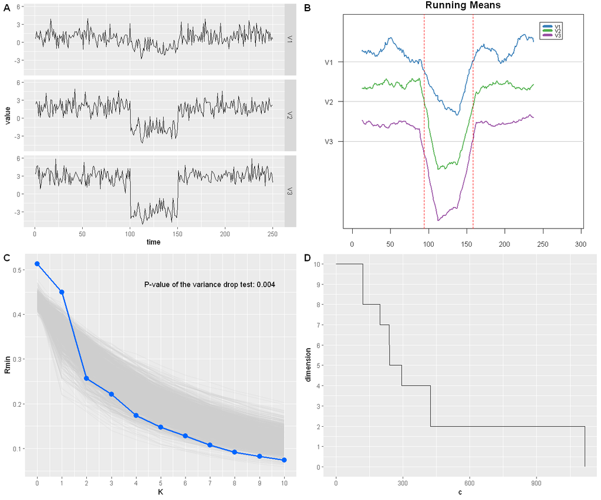

```r
options(repr.plot.width=12, repr.plot.height=10)
summary(resultMean)
plot_grid(plot_multi,
          as.grob(~plot(resultMean_2)),
          permut_plot(resultMean_2, Kmax),
          grid_plot(resultMean_2, Kmax),
          ncol=2, labels="AUTO")
```

## Other kcpRS analysis: runVar, runAR, runCorr

Let's try the other metrics.

```
SETTINGS:
    Running statistics monitored: variance
    Number of running variances monitored: 3
    Selected window size: 25
    Number of time windows: 226
    Selected maximum number of change points: 10

    Permutation test: Yes
        Number of permuted data sets used: 1000


OUTPUT:
    Number of change points detected:  0

    The KCP permutation test is NOT significant:
        Significance level: 0.05
        P-value of the variance drop test:  0.481

    Optimal change points given k:
       k   Rmin CP1 CP2 CP3 CP4 CP5 CP6 CP7 CP8 CP9 CP10
       0 0.4922   0   0   0   0   0   0   0   0   0    0
       1 0.4322 162   0   0   0   0   0   0   0   0    0
       2 0.3556 142 161   0   0   0   0   0   0   0    0
       3 0.3137  71 142 161   0   0   0   0   0   0    0
       4 0.2542  90 113 141 162   0   0   0   0   0    0
       5 0.2331  69  90 113 141 162   0   0   0   0    0
       6 0.2172  90 113 141 162 192 213   0   0   0    0
       7 0.1961  69  90 113 141 162 192 213   0   0    0
       8 0.1841  69  90 100 113 141 162 192 213   0    0
       9 0.1689  30  44  69  90 113 141 162 192 213    0
      10 0.1569  30  44  69  90 100 113 141 162 192  213
```

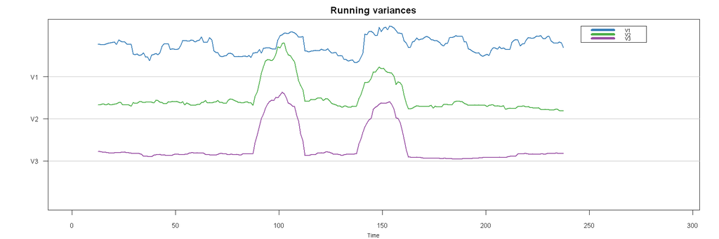

```r
options(repr.plot.width=15, repr.plot.height=5)
# runVar
resultVar = kcpRS(data = data_multi, RS_fun = runVar, RS_name = "variance",
                      wsize = 25, nperm = 1000, Kmax = 10, alpha = .05, varTest = FALSE,
                      ncpu = detectCores())
summary(resultVar)
plot(resultVar)
```

```
SETTINGS:
    Running statistics monitored: AR
    Number of running ARs monitored: 3
    Selected window size: 25
    Number of time windows: 225
    Selected maximum number of change points: 10

    Permutation test: Yes
        Number of permuted data sets used: 1000


OUTPUT:
    Number of change points detected:  0

    The KCP permutation test is NOT significant:
        Significance level: 0.05
        P-value of the variance drop test:  0.075

    Optimal change points given k:
       k   Rmin CP1 CP2 CP3 CP4 CP5 CP6 CP7 CP8 CP9 CP10
       0 0.4708   0   0   0   0   0   0   0   0   0    0
       1 0.4217  89   0   0   0   0   0   0   0   0    0
       2 0.3091  89 162   0   0   0   0   0   0   0    0
       3 0.2750  89 161 196   0   0   0   0   0   0    0
       4 0.2238  90 112 140 161   0   0   0   0   0    0
       5 0.1888  90 112 140 161 196   0   0   0   0    0
       6 0.1691  90 111 125 140 161 196   0   0   0    0
       7 0.1498  48  90 111 125 140 161 196   0   0    0
       8 0.1346  47  66  90 111 125 140 161 196   0    0
       9 0.1211  47  66  90 111 125 140 161 196 208    0
      10 0.1081  47  66  90 111 125 140 161 185 196  208
```

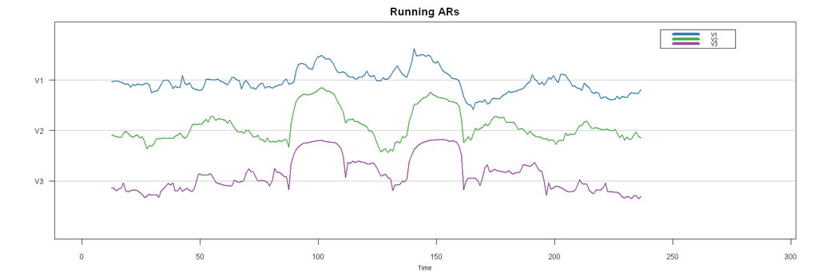

```r
# runAR
resultAR = kcpRS(data = data_multi, RS_fun = runAR, RS_name = "AR",
                      wsize = 25, nperm = 1000, Kmax = 10, alpha = .05, varTest = FALSE,
                      ncpu = detectCores())
summary(resultAR)
plot(resultAR)
```

```
SETTINGS:
    Running statistics monitored: Corr
    Number of running Corrs monitored: 3
    Selected window size: 25
    Number of time windows: 226
    Selected maximum number of change points: 10

    Permutation test: Yes
        Number of permuted data sets used: 1000


OUTPUT:
    Number of change points detected:  2
    Change point location(s):  90 163

    KCP permutation test is significant:
        Significance level: 0.05
        P-value of the variance drop test:  0

    Optimal change points given k:
       k   Rmin CP1 CP2 CP3 CP4 CP5 CP6 CP7 CP8 CP9 CP10
       0 0.5028   0   0   0   0   0   0   0   0   0    0
       1 0.4180  89   0   0   0   0   0   0   0   0    0
       2 0.1995  90 163   0   0   0   0   0   0   0    0
       3 0.1761  90 163 216   0   0   0   0   0   0    0
       4 0.1537  64  91 163 216   0   0   0   0   0    0
       5 0.1409  91 122 140 163 216   0   0   0   0    0
       6 0.1182  64  91 122 140 163 216   0   0   0    0
       7 0.0986  64  90 101 121 140 163 216   0   0    0
       8 0.0845  64  90 101 121 140 162 174 205   0    0
       9 0.0770  64  90 101 121 140 162 175 199 216    0
      10 0.0695  64  90 101 121 140 157 163 175 199  216
```

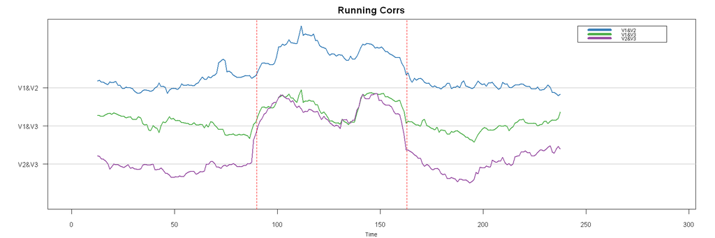

```r
# runCorr
resultCorr = kcpRS(data = data_multi, RS_fun = runCorr, RS_name = "Corr",
                      wsize = 25, nperm = 1000, Kmax = 10, alpha = .05, varTest = FALSE,
                      ncpu = detectCores())
summary(resultCorr)
plot(resultCorr)
```

# Over dyads

```r
# Data for dyads analysis
data_NC = read.csv2("data/laura_lab_data_emo_1.csv", dec=".") %>% rename(dial.1 = dial_NC.1, dial.2 = dial_NC.2) %>% mutate(type = "NC")
data_PC = read.csv2("data/laura_lab_data_emo_2.csv", dec=".") %>% rename(dial.1 = dial_PC.1, dial.2 = dial_PC.2) %>% unique() %>% mutate(type = "PC")
data_dyad = bind_rows(data_NC, data_PC) %>% group_by(Couple) %>% mutate(obs = 1:n()) %>% arrange(Couple, obs) %>% ungroup() %>% filter(Couple != 7 & Couple !=43)
```

## Time series plot

We will use the dataset from Sels et al., 2021. In a first part, for a demonstration purpose, we will only use the data from the couple 3. Note that the change point detection method can be run only one dyad at a time.

The variables of the database are the following:

- Couple: the couple's number in the experiment.
- type: there is two phases in the experiment. PC correspond to the positive interaction part and NC to the negative interaction one.
- obs: is the number of observation during the experiment.
- dial.1 are measurement of the first partner.
- dial.2 on the second one.

Let's have first a insigth on the time series.

```r
head(data_dyad)
```

| Couple | dial.1 | dial.2 | type | obs |
| --- | --- | --- | --- | --- |
| 1 | 0.3554608 | -0.006207055 | NC | 1 |
| 1 | 0.2262513 | -0.007068531 | NC | 2 |
| 1 | 0.4008866 | 0.013938817 | NC | 3 |
| 1 | 0.3677438 | 0.014468157 | NC | 4 |
| 1 | 0.3634252 | 0.007301895 | NC | 5 |
| 1 | 0.4220793 | 0.021774677 | NC | 6 |

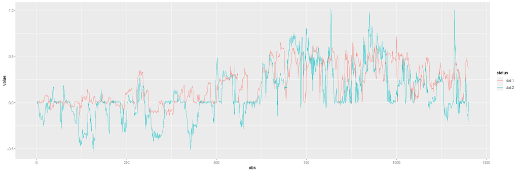

```r
options(repr.plot.width=18, repr.plot.height=6)
plot_dyad = data_dyad %>% filter (Couple == 3) %>% gather(status, value, dial.1,dial.2) %>%
                ggplot(aes(x=obs,y=value, color=status)) +
                   geom_line()
plot_dyad
```

## Over one dyad

In Sels et al., 2021, three types of similarities in dyad context and three measurements associated to each one are defined:

- **Correlation**: similarities in how partners’ emotional experiences fluctuate throughout time (**shape similarity**)
- **Instantaneous derivative matching (IDM)**: similarities in the variance of these experiences (**scatter similarity**) \begin{equation} IDM = \frac{1}{T} \sum_{t=1}^{T} |(a_{t-1} - a_{t}) - (b_{t-1} - b_{t})| \end{equation}
- **Signal matching (SM)**: similarities in the average intensity of their experiences (**level similarity**) \begin{equation} SM = \frac{1}{T} \sum_{t=1}^{T} |a_{t} - b_{t}| \end{equation}

### Creating running function: runIDM and runSM

For the IDM and the SM scores, you should create a new running function: runIDM and runSM. The code below come from the supplementary material of Sels et al., 2021.

```r
runIDM <- function(data, wsize = 25) {
  data <- as.data.frame(data)
  labs <- colnames(data)
  data <- as.matrix(data)
  N <- nrow(data)
  wstep <- 1
  windows <- floor(((N - wsize)/wstep) + 1)

  # define scores
  X <- data[,1]
  Y <- data[,2]

  # 1. difference between each time point and the subsequent time point
  # 2. compare the corresponding slopes of the two subjects at each time point
  absDiff <- matrix(NA, nrow=(length(X)-1), ncol=1)
  for (i in 1:length(absDiff)) {
    absDiff[i] <- abs((X[i+1] - X[i]) - (Y[i+1] - Y[i]))
  }

  # 3. running average slope difference
  RunIDM_TS <- roll_mean(absDiff, width = wsize)

  RunIDM_TS <- RunIDM_TS[seq(wsize, wsize + windows - 2,
                             wstep), ]
  RunIDM_TS <- as.data.frame(RunIDM_TS)
  colnames(RunIDM_TS) <- paste0(labs[1], "&", labs[2])
  return(RunIDM_TS)
}
```

```r
# SM: Signal matching
runSM <- function(data, wsize = 25) {
  data <- as.data.frame(data)
  labs <- colnames(data)
  data <- as.matrix(data)
  N <- nrow(data)
  wstep <- 1
  windows <- floor(((N - wsize)/wstep) + 1)

  # define scores
  X <- data[,1]  # Indiv1
  Y <- data[,2]  # Indiv 2

  # 1. calculate absolute difference between the score of Indiv1 and the score
  # of Indiv2 at each time point
  absDiff <- matrix(NA, nrow=length(X), ncol=1)
  for (i in 1:length(X)) {
    absDiff[i] <- abs(X[i] - Y[i])
  }

  # 2. running average absolute difference
  RunSM_TS <- roll_mean(absDiff, width = wsize)

  RunSM_TS <- RunSM_TS[seq(wsize, wsize + windows - 1,
                           wstep), ]
  RunSM_TS <- as.data.frame(RunSM_TS)
  colnames(RunSM_TS) <- paste0(labs[1], "&", labs[2])
  return(RunSM_TS)
}
```

### Run kcpRS using IDM

Then, we can use kcpRS method for, in this order, the correlation, the IDM score, the SM score.

```r
nrow(data_dyad %>% filter(Couple == 3) )
```

1200

```
SETTINGS:
    Running statistics monitored: IDM
    Number of running IDMs monitored: 1
    Selected window size: 25
    Number of time windows: 1175
    Selected maximum number of change points: 10

    Permutation test: Yes
        Number of permuted data sets used: 1000


OUTPUT:
    Number of change points detected:  1
    Change point location(s):  721

    KCP permutation test is significant:
        Significance level: 0.05
        P-value of the variance drop test:  0

    Optimal change points given k:
       k   Rmin CP1  CP2  CP3  CP4  CP5  CP6  CP7  CP8  CP9 CP10
       0 0.4439   0    0    0    0    0    0    0    0    0    0
       1 0.2807 721    0    0    0    0    0    0    0    0    0
       2 0.2510 723 1064    0    0    0    0    0    0    0    0
       3 0.2284 723 1064 1147    0    0    0    0    0    0    0
       4 0.2076 538  723 1064 1147    0    0    0    0    0    0
       5 0.1939 539  583  723 1064 1147    0    0    0    0    0
       6 0.1791 539  584  635  723 1064 1147    0    0    0    0
       7 0.1718 539  584  635  723 1064 1148 1174    0    0    0
       8 0.1602 284  314  538  584  635  723 1064 1147    0    0
       9 0.1529 284  314  538  584  635  723 1064 1148 1174    0
      10 0.1466 284  314  538  583  649  674  723 1064 1148 1174
```

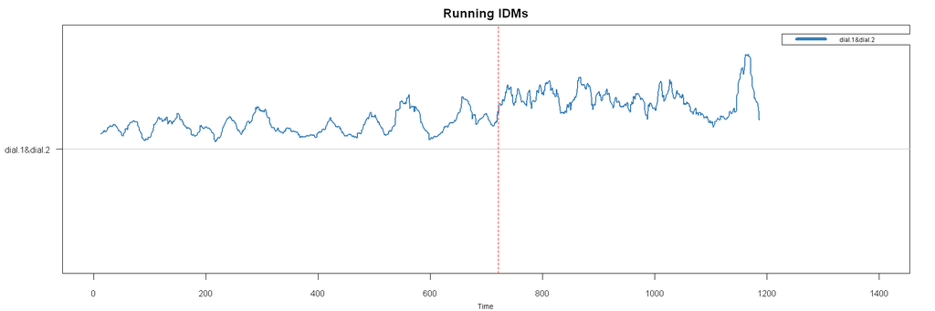

```r
# IDM
options(repr.plot.width=15, repr.plot.height=5)
data_dyad1 = data_dyad %>% filter(Couple == 3) %>% select(dial.1, dial.2)

resultIDM = kcpRS(data = data_dyad1, RS_fun = runIDM, RS_name = "IDM",
                      wsize = 25, nperm = 1000, Kmax = 10, alpha = .05, varTest = FALSE,
                      ncpu = detectCores())

summary(resultIDM)
plot(resultIDM)
```

### kcpRS analysis with runCorr, IDM and SM

Again, we can extract the permutation test and the grid search for every running statistics.

```r
# runCorr
Kmax = 10
Couple_nb = 3

dt = data_dyad %>% filter(Couple == Couple_nb) %>% select(dial.1,dial.2)

resultCorr_2 = kcpRS.mod(data = dt, RS_fun = runCorr, RS_name = "Corr",
                      wsize = 25, nperm = 1000, Kmax = Kmax, alpha = .05, varTest = FALSE,
                      ncpu = detectCores())
resultIDM_2 = kcpRS.mod(data = dt, RS_fun = runIDM, RS_name = "IDM",
                      wsize = 25, nperm = 1000, Kmax = Kmax, alpha = .05, varTest = FALSE,
                      ncpu = detectCores())
resultSM_2 = kcpRS.mod(data = dt, RS_fun = runSM, RS_name = "SM",
                      wsize = 25, nperm = 1000, Kmax = Kmax, alpha = .05, varTest = FALSE,
                      ncpu = detectCores())
```

```
[1] "Modificated version"
[1] "Modificated version"
[1] "Modificated version"
```

```r
plot_dyad_2 = data_dyad %>% filter (Couple == Couple_nb) %>% gather(status, value, dial.1,dial.2) %>%
                ggplot(aes(x=obs,y=value)) +
                   geom_line() +
                    facet_grid(status~.)

kcpRS_plots = grid.arrange(as.grob(~plot(resultCorr_2)), as.grob(~plot(resultIDM_2)), as.grob(~plot(resultSM_2)), ncol = 1)
perm_plots = grid.arrange(permut_plot(resultCorr_2, Kmax), permut_plot(resultIDM_2, Kmax), permut_plot(resultSM_2, Kmax), ncol = 1)
grid_plots = grid.arrange(grid_plot(resultCorr_2, Kmax), grid_plot(resultIDM_2, Kmax), grid_plot(resultSM_2, Kmax), ncol= 1)
```

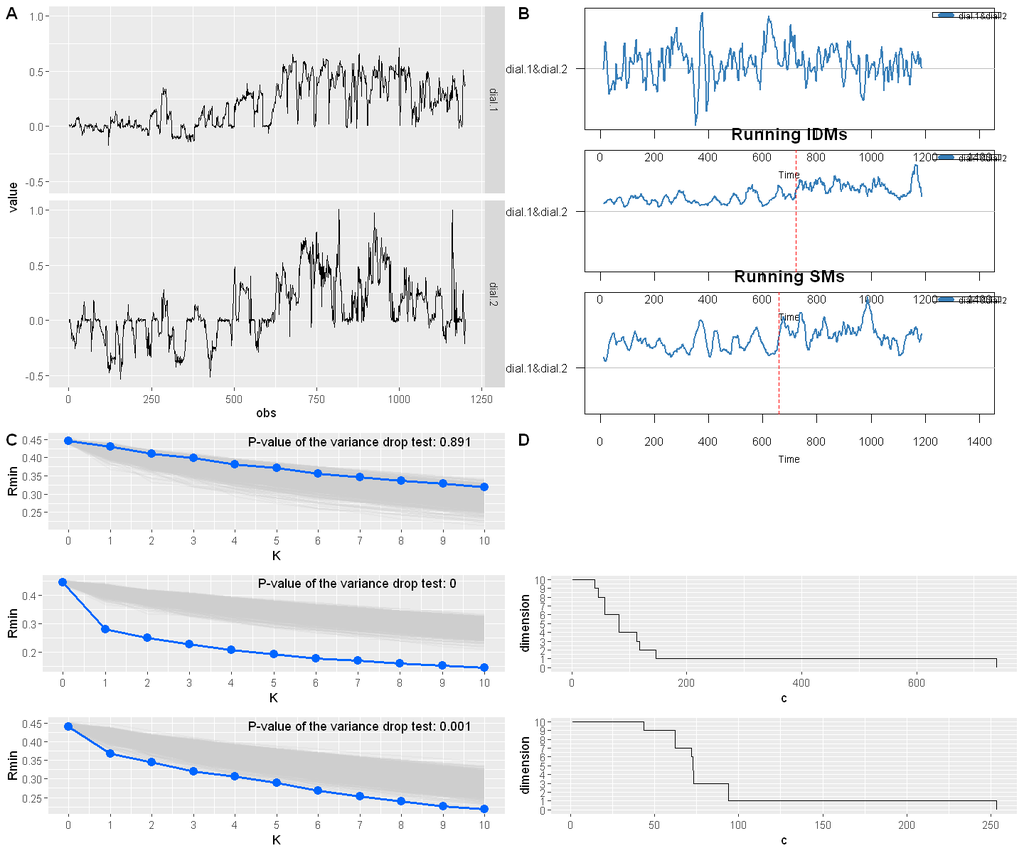

```r
options(repr.plot.width=12, repr.plot.height=10)
plot_grid(plot_dyad_2,
          kcpRS_plots,
          perm_plots,
          grid_plots,
          ncol=2, labels="AUTO")
```

## Sensitive test

A sensitive test can be run to see if the change points extracted are consistent through different window sizes. Taking the score of one couple, we will run the kcpsRS function using the IDM score for every window sizes selected (here 5).

```r
Couple_nb = 3 # Choose a dyad
```

```r
data_dyad1 = data_dyad %>% filter(Couple == Couple_nb) %>% select(dial.1, dial.2)

windows = seq(20,40,5)
results = list()
for (wsize in windows) {
    resultMean_multi = kcpRS(data = data_dyad1, RS_fun = runIDM, RS_name = "Mean",
                          wsize = wsize, nperm = 1000, Kmax = 10, alpha = .05, varTest = FALSE,
                          ncpu = detectCores())
    results[[as.character(wsize)]] = resultMean_multi$changePoints
}
```

**$`20`**

723

**$`25`**

721

**$`30`**

648

**$`35`**

645

**$`40`**

647

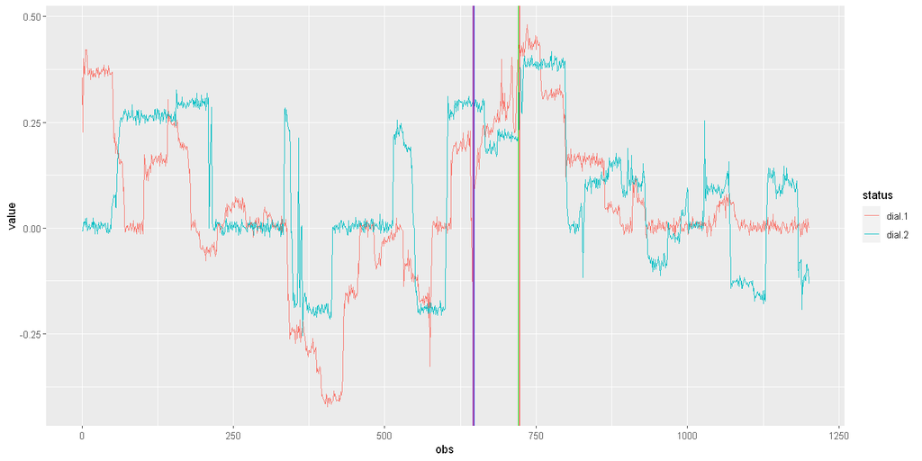

```r
options(repr.plot.width=12, repr.plot.height=6)

color = c("red","green","blue","blueviolet","coral","cyan")
plot = data_dyad %>% filter (Couple == 1) %>% gather(status, value, dial.1,dial.2) %>%
    ggplot(aes(x=obs,y=value, color=status)) +
        geom_line()

count = 1
for (i in results){
    plot = plot + geom_vline(xintercept = c(i), color=color[count])
    count = count +1
}
results
plot
```

## Over all dyads

Finally, we can run the kcpRS function for every couple and running statistic selected (i.e., correlation, IDM, MS). We can plot the results and see the different change points detected for every couple. Be careful, this operation takes a lot of time!

```r
library(tictoc)
tic()

data_dyad_tab = data_dyad # %>% filter(Couple %in% c(1:3))
data_results = data.frame()

# For every couple
for (id in unique(data_dyad_tab$Couple)){

    dt = data_dyad_tab %>% filter(Couple == id) %>% select(dial.1, dial.2)

    # Corr
    kcpRS_corr = kcpRS(data = dt, RS_fun = runCorr, RS_name = "Correlation",
                       wsize = 25, nperm = 1000, Kmax = 10, alpha = .05, varTest = FALSE,
                       ncpu = detectCores())
    corr_res = data.frame(couple = rep(id,10), type = rep("corr",10), time = c(kcpRS_corr$changePoints, rep(NA,10 - length(kcpRS_corr$changePoints))))

    # IDM
    kcpRS_IDM = kcpRS(data = dt, RS_fun = runIDM, RS_name = "IDM",
                      wsize = 25, nperm = 1000, Kmax = 10, alpha = .05, varTest = FALSE,
                      ncpu = detectCores())
    IDM_res = data.frame(couple = rep(id,10), type = rep("IDM",10), time = c(kcpRS_IDM$changePoints, rep(NA,10 - length(kcpRS_IDM$changePoints))))

    # SM
    kcpRS_SM = kcpRS(data = dt, RS_fun = runSM, RS_name = "SM",
                              wsize = 25, nperm = 1000, Kmax = 10, alpha = .05, varTest = FALSE,
                              ncpu = detectCores())
    SM_res = data.frame(couple = rep(id,10), type = rep("SM",10), time = c(kcpRS_SM$changePoints, rep(NA,10 - length(kcpRS_SM$changePoints))))

    # Save data
    data_results = bind_rows(data_results, corr_res, IDM_res, SM_res)

}

toc()
```

```
9808.14 sec elapsed
```

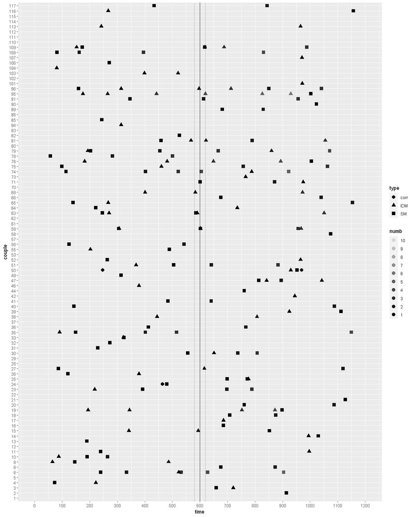

```r
library(forcats)
options(repr.plot.width=12, repr.plot.height=15)
data_results %>% group_by(couple, type) %>% mutate(numb = 1:n()) %>% ungroup() %>%
    mutate_at(vars(couple),as.factor) %>%
    mutate(numb = fct_rev(as_factor(numb)))  %>%
        ggplot(aes(x=time,y=couple)) +
            geom_point(aes(shape=type, alpha=numb), size = 3) +
            geom_vline (xintercept=600) +
            geom_vline (xintercept=c(580,620), linetype=3) +
            scale_x_continuous(limits = c(0,1200), breaks = seq(0,1200,100))
```